# R Notebook

##5. Determinar en cuantos factores o variables latentes podríamos redimensionar la data:

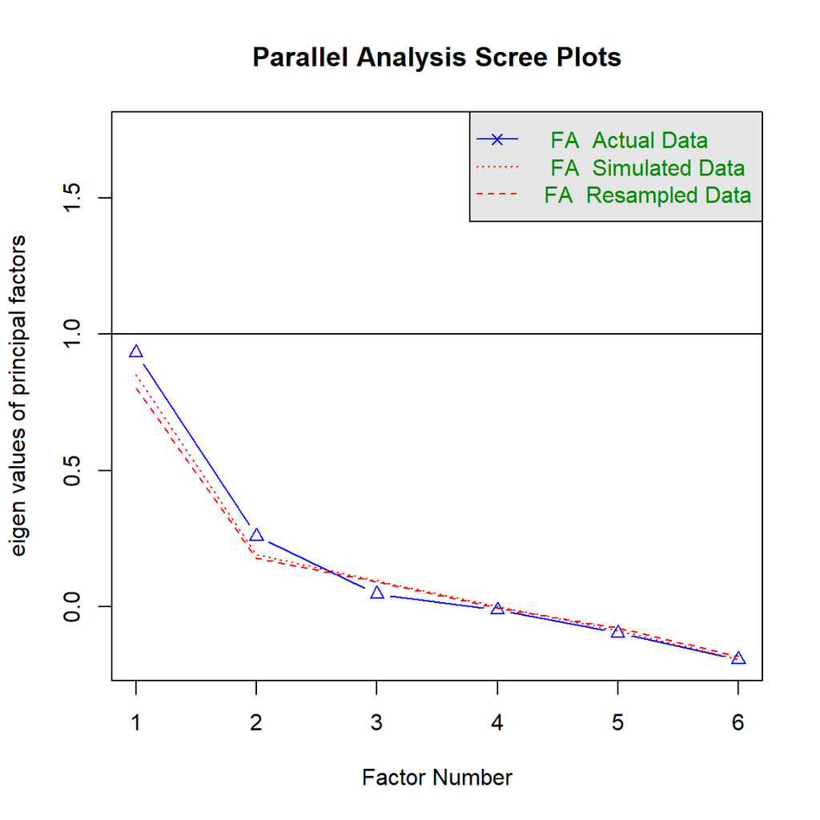

```
## Parallel analysis suggests that the number of factors =  0  and the number of components =  NA
```

```r
fa.parallel(theData,fm ='ML', fa = 'fa',correct = T)
```

##6. Redimensionar a numero menor de factores

```r
library(GPArotation)
resfa <- fa(theData,
            nfactors = 2,
            cor = 'mixed',
            rotate = "varimax",
            fm="minres")
print(resfa$loadings)
```

```
##
## Loadings:
##                 MR1    MR2
## Gasto_Edu_Total         0.340
## Gasto_Edu_Pri           0.417
## Gasto_Edu_Sec           0.621
## Indice_Gini      0.323 -0.339
## Desempleo        0.967
## PBI                     0.159
##
##                  MR1   MR2
## SS loadings    1.060 0.819
## Proportion Var 0.177 0.136
## Cumulative Var 0.177 0.313
```

```r
print(resfa$loadings,cutoff = 0.5)
```

```
##
## Loadings:
##                 MR1    MR2
## Gasto_Edu_Total
## Gasto_Edu_Pri
## Gasto_Edu_Sec           0.621
## Indice_Gini
## Desempleo        0.967
## PBI
##
##                  MR1   MR2
## SS loadings    1.060 0.819
## Proportion Var 0.177 0.136
## Cumulative Var 0.177 0.313
```

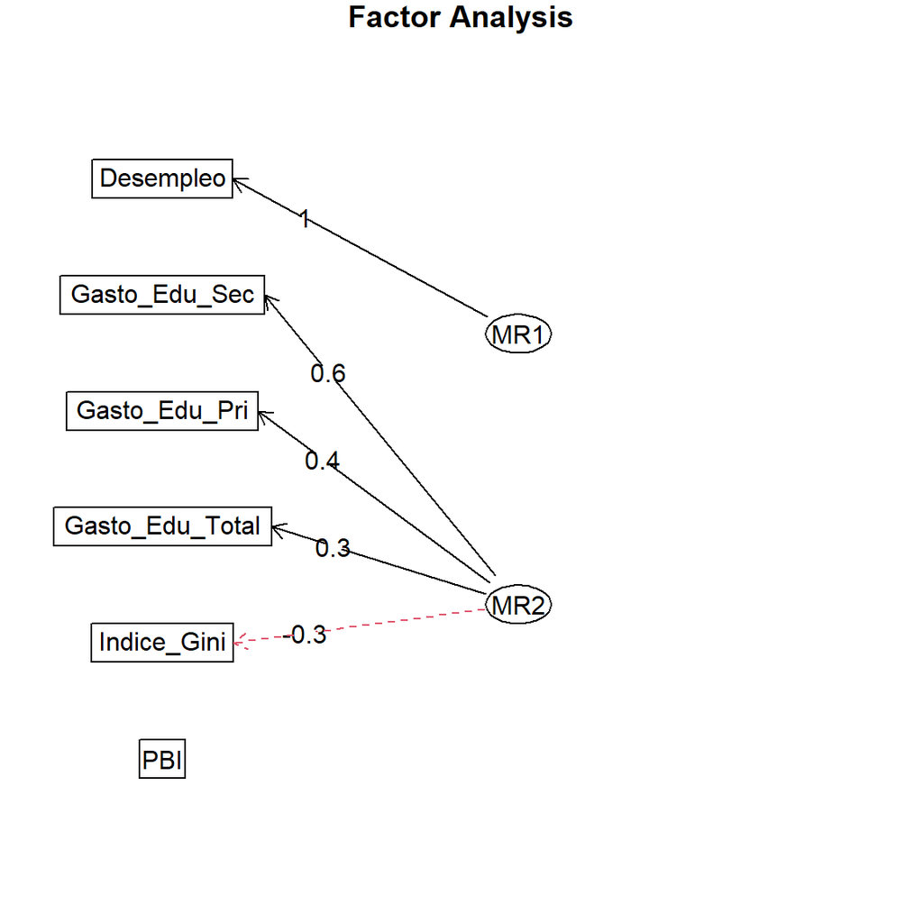

```r
#Resultado visual:

fa.diagram(resfa)
```

#Evaluando Resultado obtenido:

```r
#¿Qué variables aportaron mas a los factores?

sort(resfa$communality)
```

```
##             PBI Gasto_Edu_Total   Gasto_Edu_Pri     Indice_Gini   Gasto_Edu_Sec
##      0.03364616      0.11959261      0.18302182      0.21943684      0.38552911
##       Desempleo
##      0.93759670
```

```r
#¿Qué variables contribuyen a mas de un factor?

sort(resfa$complexity)
```

```
##   Gasto_Edu_Sec       Desempleo Gasto_Edu_Total   Gasto_Edu_Pri             PBI
##        1.000153        1.006338        1.067247        1.102782        1.594498
##     Indice_Gini
##        1.995288
```

#ANALISIS FACTORIAL CONFIRMATORIO

```r
names(TRABAJO_2)
```

```
## [1] "PAISES"          "Gasto_Edu_Total" "Gasto_Edu_Pri"   "Gasto_Edu_Sec"
## [5] "Indice_Gini"     "Desempleo"       "PBI"
```

```r
#Si la exploración apoyaba nuestro marco teórico, podemos proponer cómo construir los indices:

model <- ' Eficiente_Educación  =~ Gasto_Edu_Total + Gasto_Edu_Pri + Gasto_Edu_Sec + Indice_Gini'
```

```r
## normalizar las variables:
theDataNorm=as.data.frame(scale(theData))
```

```r
library(lavaan)
cfa_fit <- cfa(model, data=theDataNorm,
           std.lv=TRUE,
           missing="fiml")
```

##Preparo los tests:

```r
allParamCFA=parameterEstimates(cfa_fit,standardized = T)
allFitCFA=as.list(fitMeasures(cfa_fit))
```

```r
allParamCFA[allParamCFA$op=="=~",]
```

```
##                   lhs op             rhs    est    se      z pvalue ci.lower
## 1 Eficiente_Educación =~ Gasto_Edu_Total  0.348 0.125  2.775  0.006    0.102
## 2 Eficiente_Educación =~   Gasto_Edu_Pri  0.462 0.131  3.535  0.000    0.206
## 3 Eficiente_Educación =~   Gasto_Edu_Sec  0.562 0.145  3.880  0.000    0.278
## 4 Eficiente_Educación =~     Indice_Gini -0.378 0.128 -2.948  0.003   -0.630
##   ci.upper std.lv std.all std.nox
## 1    0.593  0.348   0.349   0.349
## 2    0.719  0.462   0.464   0.464
## 3    0.845  0.562   0.564   0.564
## 4   -0.127 -0.378  -0.380  -0.380
```

```r
#Prueba del ChiSquare

allFitCFA[c("chisq", "df", "pvalue")] # pvalue>0.05
```

```
## $chisq
## [1] 0.5190231
##
## $df
## [1] 2
##
## $pvalue
## [1] 0.7714283
```

#Necesitamos que el p_value debe ser mayor a 0.05 para que sea bueno; sin embargo, en la prueba del Chisquare sale mayor a con un valor de 0.7714283

```r
#Prueba del Índice Tucker Lewi

allFitCFA$tli # > 0.90
```

```
## [1] 1.222933
```

```r
#Prueba de la Raíz del error cuadrático medio

allFitCFA[c('rmsea.ci.lower','rmsea' ,'rmsea.ci.upper')] # 0.05 en el Int de Conf?
```

```
## $rmsea.ci.lower
## [1] 0
##
## $rmsea
## [1] 0
##
## $rmsea.ci.upper
## [1] 0.1148328
```

#En la prueba de la Raiz del error cuadrático medio, queremos que sea menor a 0.05, lo cual muestra en el rmsea que es 0; por lo tanto, la prueba acepta que se puede formar un factor en aquel modelo.